# Project 1: A C4.5 analysis of a Wine Quality Dataset.

Þórgnýr Thoroddsen & Anna Margrét Björnsdóttir

9/12/2017

### Data Wrangling

We start by importing the data and looking at the attributes it contains.

```r
data <- read.table("data/winequality-red.csv", header = TRUE, sep = ";", dec = ".")
str(data)
```

```
## 'data.frame':    1599 obs. of  12 variables:
##  $ fixed.acidity       : num  7.4 7.8 7.8 11.2 7.4 7.4 7.9 7.3 7.8 7.5 ...
##  $ volatile.acidity    : num  0.7 0.88 0.76 0.28 0.7 0.66 0.6 0.65 0.58 0.5 ...
##  $ citric.acid         : num  0 0 0.04 0.56 0 0 0.06 0 0.02 0.36 ...
##  $ residual.sugar      : num  1.9 2.6 2.3 1.9 1.9 1.8 1.6 1.2 2 6.1 ...
##  $ chlorides           : num  0.076 0.098 0.092 0.075 0.076 0.075 0.069 0.065 0.073 0.071 ...
##  $ free.sulfur.dioxide : num  11 25 15 17 11 13 15 15 9 17 ...
##  $ total.sulfur.dioxide: num  34 67 54 60 34 40 59 21 18 102 ...
##  $ density             : num  0.998 0.997 0.997 0.998 0.998 ...
##  $ pH                  : num  3.51 3.2 3.26 3.16 3.51 3.51 3.3 3.39 3.36 3.35 ...
##  $ sulphates           : num  0.56 0.68 0.65 0.58 0.56 0.56 0.46 0.47 0.57 0.8 ...
##  $ alcohol             : num  9.4 9.8 9.8 9.8 9.4 9.4 9.4 10 9.5 10.5 ...
##  $ quality             : int  5 5 5 6 5 5 5 7 7 5 ...
```

When we check the dataset we see that all of the attributes are numerical with good reason. We’ll be making a C4.5 decision tree to try and predict how the wines get classified in terms of quality. Let’s view the quality attribute a little closer.

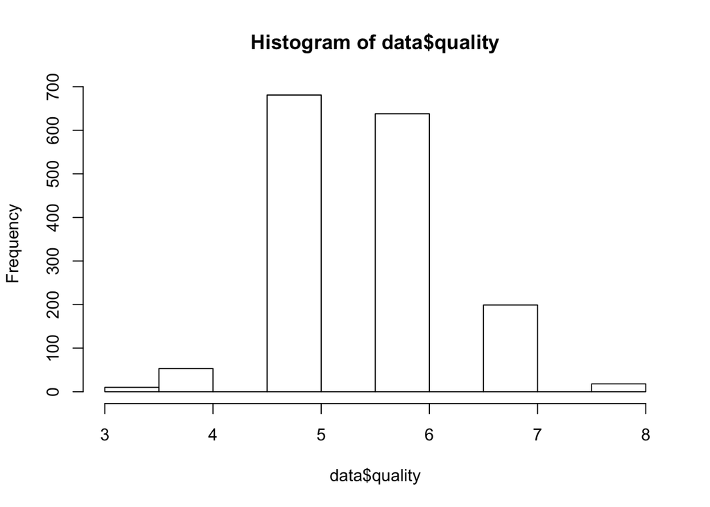

```r
hist(data$quality)
```

```r
levels(as.factor(data$quality))
```

```
## [1] "3" "4" "5" "6" "7" "8"
```

But first let’s peer a bit into the dataset:  
* There’s no missing data so we luckily don’t have to deal with that.  
* The outliers in the data do not seem to be significant. They need not be dealt with.